# Malaria Risk in India: Complete Analysis

**Capstone Project - When Machine Learning and Mechanistic Models Disagree: Who Should Policy Trust?**

Disease: Malaria | Regions: Odisha, Mizoram, Tripura (state-level, India) | Data: 2000-2024

## Notebook structure

| Section | Content |
| --- | --- |
| 1 | Exploratory Data Analysis (EDA) |
| 2 | Region Selection and Justification |
| 3 | Mandatory Geospatial Analysis |
| 4 | Model A - Mechanistic SIR Model (with R0) |
| 5 | Model B - Time-Series Forecasting: ARIMA vs SARIMA |
| 6 | Model C - Supervised ML Risk Classification (Random Forest) |
| 7 | Model Disagreement Analysis (Core Task) |
| 8 | Policy Interpretation (Most Important Section) |

Machine learning (ML) and mechanistic modeling differ primarily in their foundation: ML is data-driven, identifying patterns in large datasets without explicit knowledge of underlying rules, while mechanistic models are knowledge-driven, explicitly simulating physical, chemical or biological rules. ML offers high predictive power, whereas mechanistic models provide causal explanations.

```python
# Uncomment once if packages are missing
# %pip install pandas numpy matplotlib plotly scipy statsmodels scikit-learn
```

```python
from pathlib import Path
import json
import warnings

import numpy as np
import pandas as pd
import matplotlib.pyplot as plt
import matplotlib.ticker as mticker
import plotly.express as px

from scipy.integrate import solve_ivp
from scipy.optimize import minimize

from statsmodels.tsa.arima.model import ARIMA
from statsmodels.tsa.statespace.sarimax import SARIMAX
from statsmodels.tsa.stattools import adfuller
from statsmodels.graphics.tsaplots import plot_acf, plot_pacf

from sklearn.base import clone
from sklearn.dummy import DummyClassifier
from sklearn.ensemble import GradientBoostingClassifier, RandomForestClassifier
from sklearn.linear_model import LogisticRegression
from sklearn.metrics import (
    average_precision_score, balanced_accuracy_score,
    classification_report, confusion_matrix, ConfusionMatrixDisplay,
    mean_absolute_error, mean_squared_error,
    precision_recall_fscore_support, roc_auc_score,
    RocCurveDisplay, PrecisionRecallDisplay,
)
from sklearn.pipeline import Pipeline
from sklearn.preprocessing import StandardScaler

warnings.filterwarnings("ignore")

PROJECT_ROOT = Path.cwd().resolve()
if PROJECT_ROOT.name == "notebooks":
    PROJECT_ROOT = PROJECT_ROOT.parent
elif not (PROJECT_ROOT / "data").exists() and (PROJECT_ROOT.parent / "data").exists():
    PROJECT_ROOT = PROJECT_ROOT.parent

DATA_DIR          = PROJECT_ROOT / "data"
ANALYSIS_READY    = DATA_DIR / "analysis_ready"
RAW_DIR           = DATA_DIR / "raw"

STATE_YEAR_CSV    = ANALYSIS_READY / "state_year_malaria_clean.csv"
DISTRICT_CSV      = ANALYSIS_READY / "district_malaria_clean.csv"
AIML_FEATURES_CSV = ANALYSIS_READY / "aiml_state_year_features.csv"
GEOJSON_PATH      = RAW_DIR / "india_states.geojson"


SELECTED_REGIONS     = ["Odisha", "Mizoram", "Tripura"]
SPATIAL_SCALE        = "state-level"
TRAIN_END_YEAR       = 2016
VALIDATION_END_YEAR  = 2019
TEST_START_YEAR      = 2020
RISK_QUANTILE        = 0.75
RANDOM_STATE         = 42
HOLDOUT_STEPS        = 4
SEASONAL_PERIOD      = 4   # 4-year inter-annual epidemic cycles

print("Project root:", PROJECT_ROOT)
print("All data files exist:", all(p.exists() for p in [STATE_YEAR_CSV, DISTRICT_CSV, AIML_FEATURES_CSV, GEOJSON_PATH]))
```

```
Project root: /Users/Lenovo/Documents/New project/malaria-risk-project
All data files exist: True
```

## Section 1 - Exploratory Data Analysis (EDA)

```python
# Load datasets
state_year = pd.read_csv(STATE_YEAR_CSV)
district   = pd.read_csv(DISTRICT_CSV)
model_df   = pd.read_csv(AIML_FEATURES_CSV)

num_cols_sy = ["year","total_cases","total_deaths","district_count",
               "population_2011","cases_per_100k","deaths_per_100k"]
for c in num_cols_sy:
    state_year[c] = pd.to_numeric(state_year[c], errors="coerce")

for c in [col for col in model_df.columns if col not in {"state","selected_region"}]:
    model_df[c] = pd.to_numeric(model_df[c], errors="coerce")

print("State-year shape:",   state_year.shape)
print("District shape:",     district.shape)
print("ML-features shape:",  model_df.shape)
print("\nStates/UTs:",        state_year['state'].nunique())
print("Year range:",         int(state_year['year'].min()), "-", int(state_year['year'].max()))
display(state_year.describe())
```

```
State-year shape: (858, 9)
District shape: (16781, 8)
ML-features shape: (706, 21)

States/UTs: 38
Year range: 2000 - 2024
```

|  | year | total_cases | total_deaths | district_count | population_2011 | cases_per_100k | deaths_per_100k |
| --- | --- | --- | --- | --- | --- | --- | --- |
| count | 858.000000 | 858.000000 | 858.000000 | 858.000000 | 8.580000e+02 | 858.000000 | 858.000000 |
| mean | 2011.942890 | 33293.745921 | 18.382284 | 19.520979 | 3.467684e+07 | 256.727855 | 0.299964 |
| std | 7.227928 | 69686.950712 | 47.210206 | 15.873851 | 4.308721e+07 | 643.404588 | 1.187990 |
| min | 2000.000000 | 0.000000 | 0.000000 | 1.000000 | 6.447300e+04 | 0.000000 | 0.000000 |
| 25% | 2006.000000 | 432.250000 | 0.000000 | 7.000000 | 1.458545e+06 | 5.690454 | 0.000000 |
| 50% | 2012.000000 | 4202.000000 | 1.000000 | 16.000000 | 2.535146e+07 | 39.224678 | 0.003099 |
| 75% | 2018.000000 | 33153.250000 | 12.000000 | 30.000000 | 6.043969e+07 | 198.163083 | 0.075344 |
| max | 2024.000000 | 509497.000000 | 467.000000 | 76.000000 | 1.998123e+08 | 7866.393751 | 14.815061 |

|  | state | years_available |
| --- | --- | --- |
| 11 | Odisha | 25 |
| 16 | Mizoram | 25 |
| 19 | Tripura | 25 |

[output not shown]

[figure not shown]

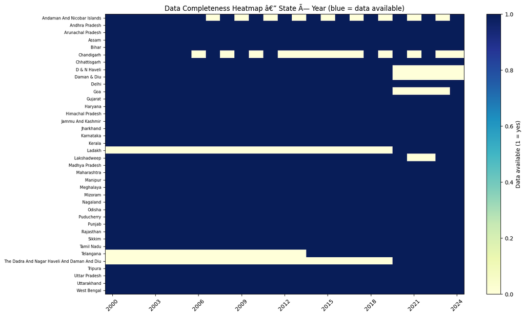

```python
# Per-state row count - how many years of data does each state contribute?
state_counts = state_year.groupby("state").size().sort_values(ascending=True).reset_index()
state_counts.columns = ["state", "years_available"]

fig, axes = plt.subplots(1, 2, figsize=(14, 6))

axes[0].barh(state_counts["state"], state_counts["years_available"], color="steelblue", alpha=0.8)
axes[0].set_title("Data Availability per State - Number of Year-Observations (2000-2024)")
axes[0].set_xlabel("Number of years with data")
axes[0].axvline(state_counts["years_available"].median(), color="red", linestyle="--",
                linewidth=1.5, label=f"Median = {state_counts['years_available'].median():.0f} years")
axes[0].legend()

# Highlight selected regions
for region in SELECTED_REGIONS:
    row_count = state_counts[state_counts["state"] == region]["years_available"].values[0]
    idx = list(state_counts["state"]).index(region)
    axes[0].barh(region, row_count, color="darkorange", alpha=0.9)

selected_counts = state_counts[state_counts["state"].isin(SELECTED_REGIONS)]
display(selected_counts)

# Why some states have fewer years: missing data or not reporting
incomplete_states = state_counts[state_counts["years_available"] < 22]
complete_states   = state_counts[state_counts["years_available"] == 22]

print(f"States with full 25-year coverage: {len(complete_states)}")
print(f"States with incomplete coverage:  {len(incomplete_states)}")
print(f"  of which selected: {[s for s in SELECTED_REGIONS if s in incomplete_states['state'].values]}")

# Data completeness matrix heatmap-style
year_matrix = state_year.pivot_table(index="state", columns="year",
                                      values="total_cases", aggfunc="sum")
fig, ax = plt.subplots(figsize=(14, 8))
im = ax.imshow(year_matrix.notna().astype(int), aspect="auto", cmap="YlGnBu", interpolation="nearest")
ax.set_xticks(range(0, len(year_matrix.columns), 3))
ax.set_xticklabels(year_matrix.columns[::3], rotation=45)
ax.set_yticks(range(len(year_matrix)))
ax.set_yticklabels(year_matrix.index, fontsize=7)
ax.set_title("Data Completeness Heatmap - State x Year (blue = data available)")
plt.colorbar(im, ax=ax, label="Data available (1 = yes)")
plt.tight_layout()
plt.show()
```